# A3: SPL Library Checkouts

### Introduction

The dataset that I am parsing and analyzing comes from Seattle Public Library where the dataset is with all items checked out at least 10 times a month from 2017-2023.

For the data I answered a few of the following questions which included looking at the average number of checkouts per checkout type, and seeing which checkout type had the highest average number of checkouts. I also wanted to discover what the year with most and least checkouts for the book “Meditations” was because I think meditation became more popular to decrease stress after the pandemic occurred. Then I also wanted to see which year had the highest and lowest Ebook checkouts which also relates towards seeing patterns that occurred during the pandemic when libraries were closed. Another question I choose to analyze was looking at the average number of checkouts for a material type, looking specifically at audio books, as audio books seem to have become more popular due to accessibility especially after the pandemic. Finally, I chose to look at a specific author, Jo Walton, because she is a popular author I heard of who received awards and writes an interesting combination of genres that include poetry, science fiction, and fantasy. So, I wanted to see which year she had the most checkouts.

For creating graphical information I made three charts that looked at trends over time, I was interested in understanding more of how the COVID-19 pandemic impacted trends. I wanted to discover how certain authors had impacts on checkouts over the years, how different medium types would change throughout the years and checkout types would fluctate, and see if the pandemic did have any impact. The three charts include the total checkouts among top 5 creators by year, total checkouts by material type by year, and the total checkouts by the checkout types by year.

### Summary Information

For the exploration of the Seattle Public Library data set I was able to find the values calculated from the summary information R Script. Firstly, I found that the highest average number of checkout type was Zinio, average of 61 checkouts. Then I found out that 2022 had the maximum checkouts for Meditations while 2023 had lowest number of checkouts for that book. Further, I discovered that 2020 had the highest checkouts for Ebooks, and 2023 had the lowest checkouts for Ebooks. To answer my question about audio books, I found out the average number of checkouts for audio books is 25 checkouts. Lastly, for my question regarding Jo Walton, he had the most checkouts in 2021.

### The Dataset

- Who collected/published the data? The Seattle Public Library collected and published the data.
- What are the parameters of the data (dates, number of checkouts, kinds of books, etc.)? The parameters of the data include usage class, checkout types, material type, checkout year, checkout month, number of checkouts, titles, ISBN, creator, subjects, publisher, and publication year. There are 816,354 observations(rows) in the dataset. There are 12 features (columns) in the data.
- How was the data collected or generated? The data was collected/generated by the City of Seattle’s Open Data Initiative, further George Legrady’s installation was able to collect checkout data for 12 years.
- Why was the data collected? The data was collected to help learn more about the local communities and culture behind them. Inn addition, trends and patterns can be analyzed which can help ask questions about the Seattle communities. This was done through understanding the types of books that were being checked out, including social justice and Black history books. Further, the Open Data Initiative allowed for transparency and collaboration that enabled public problem solving where the data collected would come into play.
- What, if any, ethical questions do you need to consider when working with this data? Some ethical questions to consider when working with this data is that it can be potentially misused in a negative way that could harm people. Since the data set is open to the public, news sources and other individuals can create visuals that are misinformation when using the open data, therefore misleading the public or whoever that encounters their created visual. Potentially, it can shed negative light onto various authors or publishers based on this visuals.
- What are possible limitations or problems with this data? (at least 200 words) Some possible limitations or problems with the data include the fact that there are a lot of missing data pieces within the dataset. This includes missing creators, subjects, publishers, and publication years, just to name a few. This can lead to skewed results when trying to work with the data due to these missing data values. In addition, on the seattle.gov website that holds the data, there is not a clear description of how and why the data was gathered. I had to look at outside sources to determine the how and why of the data that is gathered. Another issue is that the data only is limited to a few years starting from 2017, this means that there is a lot of historically missing data that was not yet collected. Also, my visualizations only calculate up until the beginning of 2023, as 2023 has not started, which could skew some of my statistical results. Further, if looking at the public year column, the formatting is not all the same, which can make parsing the data challenging. If looking at the social justice area, the ethnicities of the authors are not listed, which is limiting as it is hard to find what cultures they are from and find patterns that show what background popular authors come from. Collecting this information could be helpful because it allows for recognizing patterns, and uplift authors from diverse ethnicities and cultures.

### Total Checkouts by the Top 5 Creators By Year

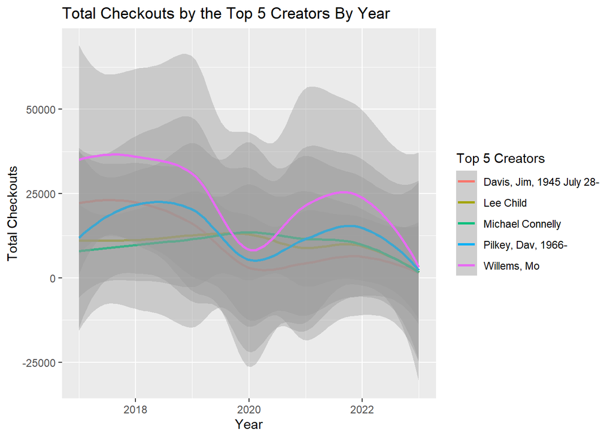

This chart demonstrates the top 5 creators, or authors with the most total checkouts and how their checkout totals ranged between years 2017-2023. This chart was included because it reveals key patterns and information that shows how popular each of the authors are throughout the time period that the data was collected. I noticed in the year 2020 (around the start of the pandemic), authors named Davis, Willems, and Pilkey dipped in checkouts while Connelly and Child increased in checkouts. Also, I noticed the pattern where Willems was the most popular author out of the top 5, with a lot of checkouts earlier in the timeframe than later.

### Total Checkouts by Material Type by Year

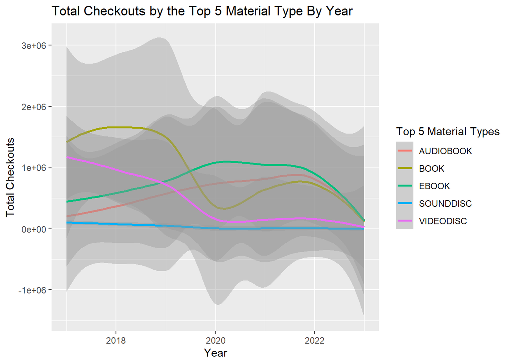

I wanted to include this chart to understand how the material type of book changed in popularity throughout the years, especially after the pandemic. Some patterns I noticed was that books had one of the steepest dips in total checkouts. Also, sound discs had a relatively flat trend line over time. Video discs also tappered off towards 2020 and beyond. Audio books rose in popularity over time.

### Total Checkouts by the Checkout Types By Year

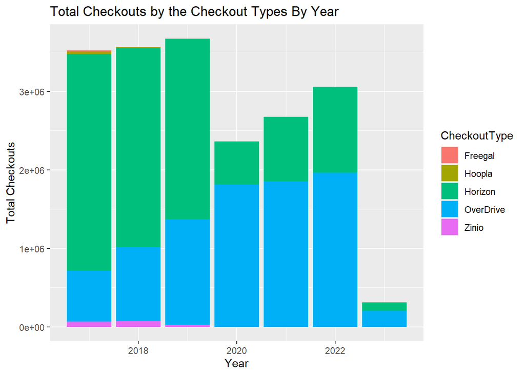